# Housing Subsidy

Shreya Bansal

2023-11-03

```r
knitr::opts_chunk$set(echo = TRUE, warning = FALSE, message = FALSE, fig.align = 'left')
#install.packages("knitr")
library(tidyverse)
library(kableExtra)
library(caret)
library(knitr)
library(pscl)
library(plotROC)
library(pROC)
library(lubridate)
library(gridExtra)
#conflicts_prefer(dplyr::filter)

# data directory
source("https://raw.githubusercontent.com/urbanSpatial/Public-Policy-Analytics-Landing/master/functions.r")

root.dir = "https://raw.githubusercontent.com/urbanSpatial/Public-Policy-Analytics-Landing/master/DATA/"
housingsub <- read.csv(file.path(root.dir,"/Chapter6/housingSubsidy.csv"))

palette5 <- c("#981FAC","#CB0F8B","#FF006A","#FE4C35","#FE9900")
palette4 <- c("#981FAC","#FF006A","#FE4C35","#FE9900")
palette2 <- c("#981FAC","#FF006A")
palette1 <- c("#88BB92","#DD696D")
```

## The Emil City Home repair tax credit program

This report looks at building a regresion model and employing data-driven approaches for Emil City to help improve their outreach strategy for a home repair tax credit program. Since the goal is to increase number of participants and reduce the money spent on marketing, this report aims to study previous data and help identify specific target audiences for the product.

### Methodology

- **Build a Classification Model:** This model will use a sample of data from previous outreach campaigns to predict whether a homeowner is likely to enter the tax credit program or not. It will sort homeowners into two categories: those likely to participate and those unlikely to participate.
- **Cost/Benefit Analysis:** This involves evaluating the financial costs associated with their outreach efforts (marketing and other resources) against the benefits gained by having more homeowners enter the program. The goal is to determine the effectiveness of the outreach and to allocate the limited resources more strategically.

### Feature importance

The following graphs show the number of people that opted into the program in red and those who didn’t in green. Features with numeric values are shown below to understand what features increased the likelihood of someone opting for the program. Let’s look at what each of them mean:

1. **Age**: The average age of those that opted for the program is very similar to those who didn’t. This feature doesn’t really tell us whether the persuaded target audience was of a certain age.
2. **Consumer confidence index at time of campaign (`cons.conf.idx`)**: Similarly, the index is even for those with chose the program and those who didn’t.
3. **Consumer Price Index at campaign time (`cons.price.idx`)** : This indicator is also similarly vague. The index is even for those who chose the program and those who didn’t.
4. **Inflation rate at the time of campaign (`inflation_rate`)**: It seems that when the US inflation rate was high, people were more likely to not opt in this program and when it was low ~ 2, more people were likely to opt in.
5. **Previous number of contacts before this campaign for the individual (`previous`)**: When the number of times the individual was previously contacted before this campaign is high, the outcome is yes.
6. **Amount annually spent on home repairs (`spent_on_repair`)**: This indicator doesn’t tell us much because the likelihood of someone opting in or not is evenly spread.
7. **Unemployment rate at time of campaign**: When the rate of unemployment on the day of contact (`unemploy_rate`) is low(or negative), the outcome is yes. When it is high, the outcome is no.

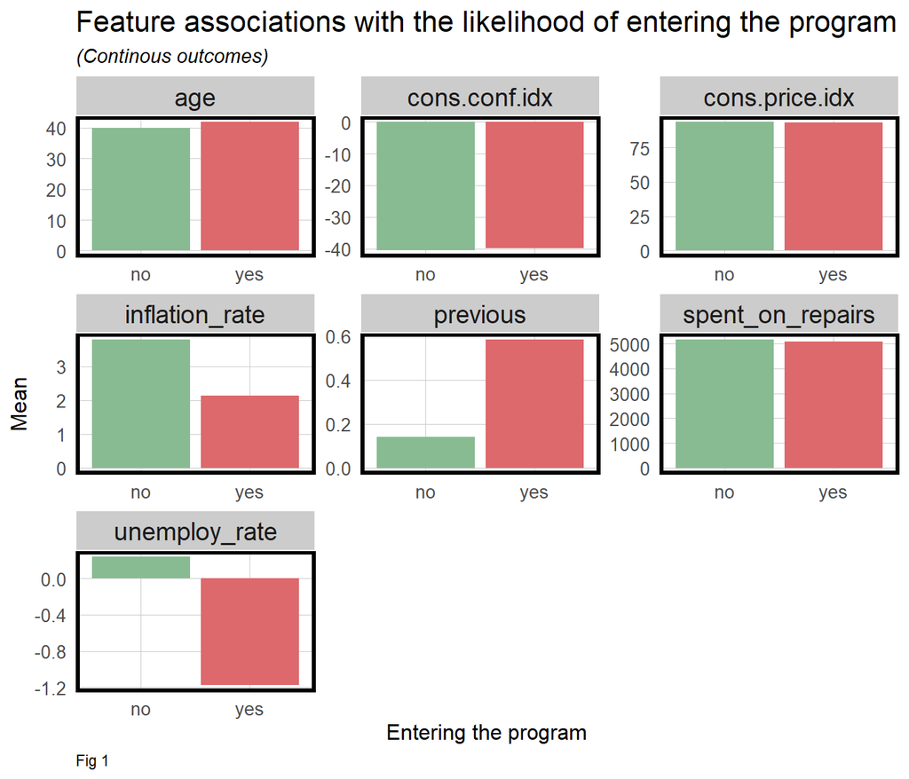

```r
housingsub %>%
  dplyr::select(y, age, previous, unemploy_rate, cons.price.idx, cons.conf.idx, inflation_rate, spent_on_repairs) %>%
  gather(Variable, value, -y) %>%
  ggplot(aes(y, value, fill=y)) +
    geom_bar(position = "dodge", stat = "summary", fun = "mean") +
    facet_wrap(~Variable, scales = "free") +
    scale_fill_manual(values = palette1) +
    labs(x="Entering the program", y="Mean",
         title = "Feature associations with the likelihood of entering the program",
         subtitle = "(Continous outcomes)", caption= "Fig 1") +
    plotTheme() + theme(legend.position = "none")
```

The following graphs show the number of people that opted into the program in red and those who didn’t in green. Features with categorical values are shown below to understand what features increased the likelihood of someone opting for the program. Let’s look at what each of them mean:

1. **Number of contacts for this individual for this campaign (`campaign`)** : This graph doesn’t necessarily show us any relationship between the number of times someone was contacted and their likelihood of opting in.
2. **How have we previously contacted individual (`contact`)**: in the volume of people contacted by cellular and telephone, it seems like cellular contacts were more successful. this is not conclusive because the number of contacts in cellular that said no are 2400 and yes are 400 and telephone are 1400 nos and 100 yeses. These are proportionate to total number of people contacted.
3. **Day of week**: Again, not much influence of the day people were contacted and their likelihood of saying yes to the program
4. **education**: It seems like more people with university degree were contacted and proportionately, more of them said yes.
5. **job**: Jobs show a similar pattern; more admins and technicians were contacted and hence more of them said yes.
6. **marital status**: The likelihood of opting in the program on the basis of marital status was also not pronounced.
7. **month**: More people were contacted in May than any other month and hence more people said yes in May.
8. **mortgage**: lesser people contacted did not have mortgage but equal number of people opted for the program
9. **Outcome of the previous marketing campaign (`poutcome`)**: looking at failure, it seems from the failure category that people that said no before did not opt for this program too.
10. **Is the owner’s full time residence not in Philadelphia (`taxbill_in_phl`)**: More people don’t live in Philly and they are the ones that said yes more often
11. **Tax Lien**: Most peope don’t have Tax Lien, only one did and they said no to the program.

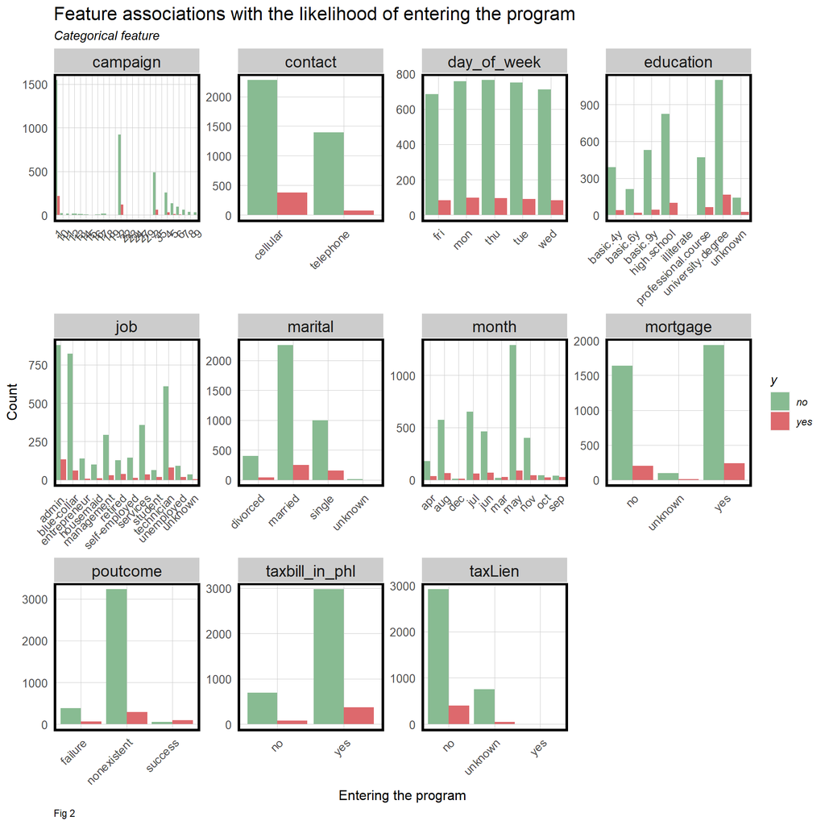

```r
housingsub %>%
  dplyr::select(y, taxbill_in_phl, contact, job, marital, education, taxLien, mortgage, month, day_of_week, poutcome, campaign) %>%
  gather(Variable, value, -y) %>%
  count(Variable, value, y) %>%
    ggplot(., aes(value, n, fill = y)) +
      geom_bar(position = "dodge", stat="identity") +
      facet_wrap(~Variable, scales = "free") +
      scale_fill_manual(values = palette1) +
      labs(x="Entering the program", y="Count",
           title = "Feature associations with the likelihood of entering the program",
           subtitle = "Categorical feature", caption= "Fig 2") +
      plotTheme() + theme(axis.text.x = element_text(angle = 45, hjust = 1))
```

## Modeling

### Kitchen sink model

```r
set.seed(34)
trainIndex <- caret::createDataPartition(housingsub$y, p = .65,
                                  list = FALSE,
                                  times = 1)
subsidyTrain <- housingsub[ trainIndex,]
subsidyTest  <- housingsub[-trainIndex,]

subsidyModel <- glm(y_numeric ~ .,
                  data=subsidyTrain %>%
                  dplyr::select(-y, -X),
                  family="binomial" (link="logit"))
#summary(subsidyModel)
pR2(subsidyModel)
```

```
## fitting null model for pseudo-r2
```

```
##          llh      llhNull           G2     McFadden         r2ML         r2CU
## -699.7319118 -926.8710680  454.2783123    0.2450601    0.1559724    0.3123180
```

Because the sensitivity (True Positive Rate) for the above model with all the features is very low, we will engineer new features that significantly increase the Sensitivity.

### Engineer new features

```r
# histogram(housingsub$pdays)
# housingsub$campaign <- as.numeric(housingsub$campaign)
# histogram(housingsub$campaign)
# summary(housingsub)
```

```r
# try re-categorize
engineered_subsidy <-
  housingsub %>%
  mutate(education,
         education = case_when(education == "basic.4y" ~ "elem",
                               education == "basic.6y" ~ "elem",
                               education == "basic.9y" ~ "high",
                               education == "high.school" ~ "high",
                               education == "professional.course" ~ "advanced",
                               education == "university.degree" ~ "advanced",
                               education == "illiterate"  ~ "basic",
                               education == "unknown" ~ "basic")) %>%
# mutate(campaign, campaign = if_else(campaign == "1", "1", "other")) %>%
 mutate(job, job = if_else(job == "retired", "retired", "other")) %>%
 mutate(pdays,
        pdays = case_when(pdays == "0"  ~ "recent",
                          pdays == "1" ~ "recent",
                          pdays == "2" ~ "recent",
                          pdays == "3" ~ "recent",
                          pdays == "4" ~ "recent",
                          pdays == "5" ~ "recent",
                          pdays == "6" ~ "recent",
                          pdays == "7" ~ "1-2 weeks",
                          pdays == "9"  ~ "1-2 weeks",
                          pdays == "10"  ~ "1-2 weeks",
                          pdays == "11"  ~ "1-2 weeks",
                          pdays == "12"  ~ "1-2 weeks",
                          pdays == "13"  ~ "1-2 weeks",
                          pdays == "14"  ~ "1-2 weeks",
                          pdays == "15"  ~ "more than 2 weeks",
                          pdays == "16" ~ "more than 2 weeks",
                          pdays == "17" ~ "more than 2 weeks",
                          pdays == "18" ~ "more than 2 weeks",
                          pdays == "19"~ "more than 2 weeks",
                          pdays == "20" ~ "more than 2 weeks",
                          pdays == "21" ~ "more than 2 weeks",
                          pdays == "999" ~ "never")) %>%
   dplyr::select(-taxbill_in_phl, -inflation_rate, -taxLien)
```

### Engineered model

```r
engineered_subsidyTrain <- engineered_subsidy[ trainIndex,]
engineered_subsidyTest  <- engineered_subsidy[-trainIndex,]

engineered_subsidyModel <- glm(y_numeric ~ .,
                  data=engineered_subsidyTrain %>%
                  dplyr::select(-y, -X),
                  family="binomial" (link="logit"))

#summary(engineered_subsidyModel)
pR2(engineered_subsidyModel)
```

```
## fitting null model for pseudo-r2
```

```
##          llh      llhNull           G2     McFadden         r2ML         r2CU
## -703.2407640 -926.8710680  447.2606080    0.2412744    0.1537586    0.3078850
```

```r
#pROC::auc(testProbs$Outcome, testProbs$Probs)
```

### Regression Summaries

```r
summary(subsidyModel)
```

```
##
## Call:
## glm(formula = y_numeric ~ ., family = binomial(link = "logit"),
##     data = subsidyTrain %>% dplyr::select(-y, -X))
##
## Coefficients:
##                                Estimate Std. Error z value Pr(>|z|)
## (Intercept)                  -1.291e+02  1.265e+02  -1.021 0.307456
## age                           1.502e-02  8.639e-03   1.738 0.082128 .
## jobblue-collar                6.319e-02  2.811e-01   0.225 0.822169
## jobentrepreneur              -7.193e-02  4.752e-01  -0.151 0.879677
## jobhousemaid                  6.361e-02  5.278e-01   0.121 0.904067
## jobmanagement                -1.980e-01  3.095e-01  -0.640 0.522350
## jobretired                   -2.865e-01  3.929e-01  -0.729 0.465783
## jobself-employed             -6.223e-01  4.449e-01  -1.399 0.161918
## jobservices                  -4.562e-02  2.941e-01  -0.155 0.876718
## jobstudent                    4.379e-02  4.416e-01   0.099 0.921015
## jobtechnician                 9.888e-02  2.539e-01   0.389 0.696933
## jobunemployed                 4.987e-01  3.867e-01   1.289 0.197225
## jobunknown                   -6.044e-01  8.782e-01  -0.688 0.491356
## maritalmarried                3.022e-01  2.702e-01   1.118 0.263449
## maritalsingle                 3.155e-01  3.070e-01   1.028 0.304118
## maritalunknown               -1.084e+01  3.842e+02  -0.028 0.977489
## educationbasic.6y             4.803e-02  4.371e-01   0.110 0.912497
## educationbasic.9y             2.476e-01  3.265e-01   0.758 0.448267
## educationhigh.school          3.132e-01  3.181e-01   0.985 0.324717
## educationilliterate          -1.272e+01  8.827e+02  -0.014 0.988500
## educationprofessional.course  2.274e-01  3.598e-01   0.632 0.527447
## educationuniversity.degree    2.137e-01  3.291e-01   0.649 0.516155
## educationunknown              7.170e-02  4.571e-01   0.157 0.875364
## taxLienunknown                2.408e-01  2.124e-01   1.134 0.256965
## mortgageunknown              -4.970e-01  5.700e-01  -0.872 0.383292
## mortgageyes                  -3.068e-01  1.482e-01  -2.071 0.038351 *
## taxbill_in_phlyes             6.817e-02  1.991e-01   0.342 0.732102
## contacttelephone             -1.058e+00  3.056e-01  -3.462 0.000536 ***
## monthaug                      2.605e-01  4.710e-01   0.553 0.580255
## monthdec                      1.145e+00  7.492e-01   1.529 0.126315
## monthjul                      1.929e-01  4.071e-01   0.474 0.635587
## monthjun                      6.095e-01  4.757e-01   1.281 0.200092
## monthmar                      2.056e+00  5.619e-01   3.659 0.000253 ***
```

[output cut: 13 more lines]

```
## unemploy_rate                -8.103e-01  4.819e-01  -1.682 0.092639 .
## cons.price.idx                1.320e+00  8.356e-01   1.579 0.114231
## cons.conf.idx                 4.443e-02  2.918e-02   1.523 0.127879
## inflation_rate                5.912e-02  4.594e-01   0.129 0.897588
## spent_on_repairs              8.571e-04  1.031e-02   0.083 0.933754
## ---
## Signif. codes:  0 '***' 0.001 '**' 0.01 '*' 0.05 '.' 0.1 ' ' 1
##
## (Dispersion parameter for binomial family taken to be 1)
##
##     Null deviance: 1853.7  on 2678  degrees of freedom
## Residual deviance: 1399.5  on 2628  degrees of freedom
## AIC: 1501.5
##
## Number of Fisher Scoring iterations: 13
```

```r
summary(engineered_subsidyModel)
```

```
##
## Call:
## glm(formula = y_numeric ~ ., family = binomial(link = "logit"),
##     data = engineered_subsidyTrain %>% dplyr::select(-y, -X))
##
## Coefficients:
##                          Estimate Std. Error z value Pr(>|z|)
## (Intercept)            -1.341e+02  1.056e+02  -1.270 0.203958
## age                     1.459e-02  8.197e-03   1.780 0.075128 .
## jobretired             -2.994e-01  3.575e-01  -0.837 0.402346
## maritalmarried          3.350e-01  2.692e-01   1.244 0.213335
## maritalsingle           3.500e-01  3.037e-01   1.153 0.249047
## maritalunknown         -1.090e+01  3.845e+02  -0.028 0.977382
## educationbasic         -1.505e-01  3.841e-01  -0.392 0.695188
## educationelem          -9.469e-02  2.364e-01  -0.401 0.688729
## educationhigh           9.702e-02  1.634e-01   0.594 0.552604
## mortgageunknown        -5.969e-01  5.449e-01  -1.095 0.273358
## mortgageyes            -2.970e-01  1.474e-01  -2.014 0.043959 *
## contacttelephone       -1.036e+00  3.023e-01  -3.428 0.000607 ***
## monthaug                2.691e-01  4.631e-01   0.581 0.561174
## monthdec                1.183e+00  7.155e-01   1.653 0.098393 .
## monthjul                2.272e-01  4.000e-01   0.568 0.570010
## monthjun                6.153e-01  4.681e-01   1.314 0.188722
## monthmar                2.078e+00  5.340e-01   3.892 9.96e-05 ***
## monthmay               -1.196e-01  3.428e-01  -0.349 0.727236
## monthnov               -2.037e-01  3.893e-01  -0.523 0.600857
## monthoct                3.431e-01  4.944e-01   0.694 0.487627
## monthsep                5.556e-01  5.990e-01   0.927 0.353693
## day_of_weekmon         -2.992e-01  2.296e-01  -1.303 0.192691
## day_of_weekthu         -1.603e-01  2.264e-01  -0.708 0.478999
## day_of_weektue         -1.624e-01  2.339e-01  -0.695 0.487299
## day_of_weekwed          5.809e-02  2.289e-01   0.254 0.799687
## campaign               -8.733e-02  4.478e-02  -1.950 0.051138 .
## pdaysmore than 2 weeks -7.111e-01  1.168e+00  -0.609 0.542586
## pdaysnever             -6.567e-01  7.850e-01  -0.837 0.402845
## pdaysrecent             2.470e-01  5.750e-01   0.430 0.667529
## previous                6.860e-02  1.835e-01   0.374 0.708551
## poutcomenonexistent     4.850e-01  3.188e-01   1.521 0.128171
## poutcomesuccess         1.104e+00  7.415e-01   1.489 0.136358
## unemploy_rate          -7.670e-01  4.745e-01  -1.616 0.106008
## cons.price.idx          1.351e+00  7.580e-01   1.782 0.074706 .
## cons.conf.idx           4.622e-02  2.051e-02   2.253 0.024270 *
## spent_on_repairs        1.369e-03  6.952e-03   0.197 0.843862
## ---
## Signif. codes:  0 '***' 0.001 '**' 0.01 '*' 0.05 '.' 0.1 ' ' 1
##
## (Dispersion parameter for binomial family taken to be 1)
##
##     Null deviance: 1853.7  on 2678  degrees of freedom
## Residual deviance: 1406.5  on 2643  degrees of freedom
## AIC: 1478.5
##
## Number of Fisher Scoring iterations: 13
```

### Cross validation

compare and interpret two facetted plots of ROC, Sensitivity and Specificity. See below fig 3 which shows the ROC, sensitivity and specificity for the kitchen sink model. Figure 4 below shows the same for the engineered model. The tighter each distribution is to its mean, the more generalizable the model. The models generalize well with respect to specificity but not sensitivity.

1. **ROC**: The mean line (purple) lies close to 0.75. Most values seem to be near the mean line. This means that the ROC is a good fit for both the models.
2. **Sensitivity**: Although both models have similar sensitivity and have a mean clise to 0.25, they both seem to have many outliers towards the right. This means that the models both perform well but cannot explain many outliers.
3. **Specificity**: The mean for both models is close to 1.

The distribution of ROC looks like its more concentrated in the higher values for the engineered model, indicating a better fit.

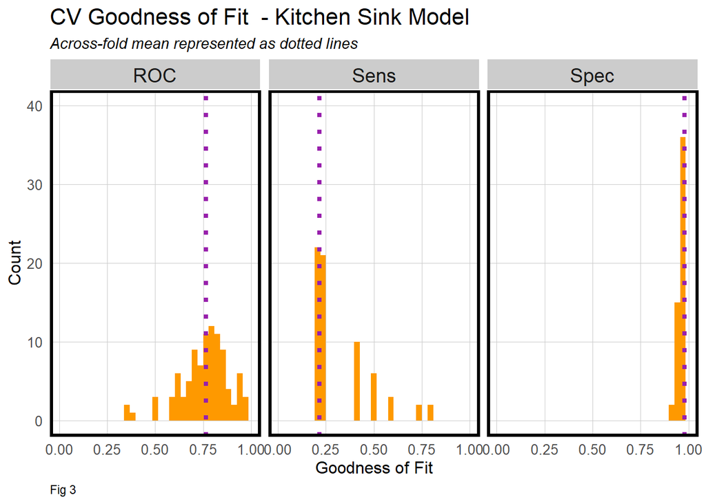

```r
ctrl <- trainControl(method = "cv", number = 100, classProbs=TRUE, summaryFunction=twoClassSummary)

cvFit <- train(y ~ ., data = housingsub %>%
                 dplyr::select(-y_numeric, -X) %>%
                 dplyr::mutate(y = ifelse(y == "no", "yes", "no")),
                 method="glm", family="binomial",
                 metric="ROC", trControl = ctrl)

dplyr::select(cvFit$resample, -Resample) %>%
  gather(metric, value) %>%
  left_join(gather(cvFit$results[2:4], metric, mean)) %>%
  ggplot(aes(value)) +
    geom_histogram(bins=35, fill = "#FE9900") +
    facet_wrap(~metric) +
    geom_vline(aes(xintercept = mean), colour = "#981FAC", linetype = 3, size = 1.5) +
    scale_x_continuous(limits = c(0, 1)) +
    labs(x="Goodness of Fit", y="Count", title="CV Goodness of Fit  - Kitchen Sink Model",
         subtitle = "Across-fold mean represented as dotted lines", caption= "Fig 3") +
    ylim(0, 40) +
    plotTheme()
```

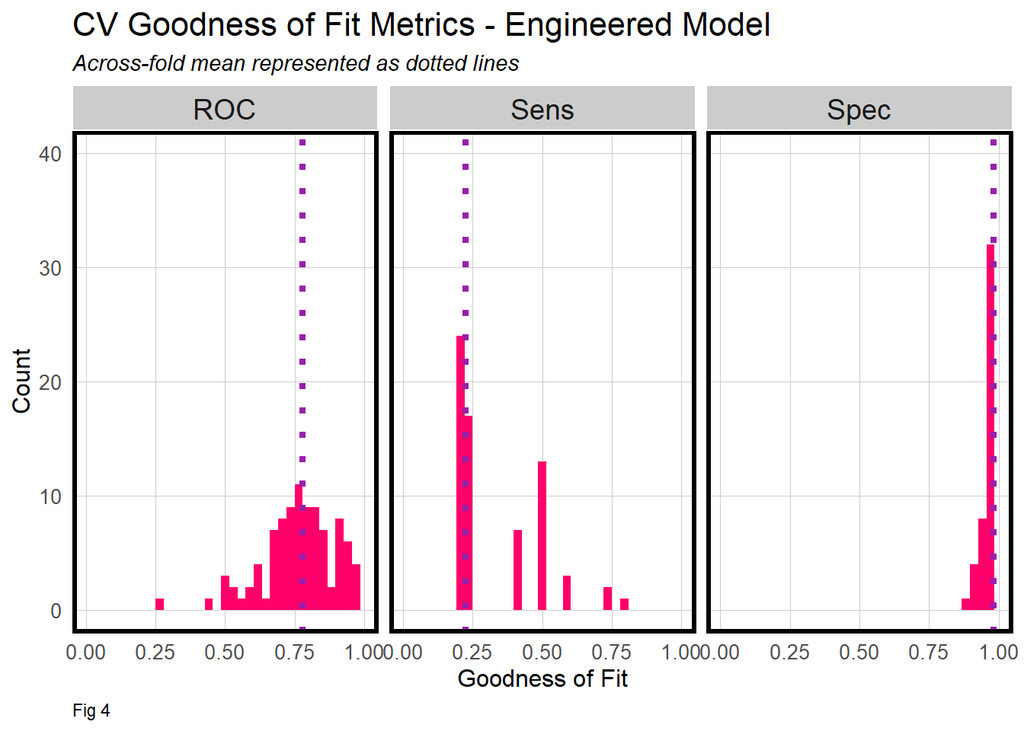

```r
engineered_cvFit <- train(y ~ ., data = engineered_subsidy %>%
                  dplyr::select(-y_numeric, -X) %>%
                 dplyr::mutate(y = ifelse(y == "no", "yes", "no")),
                method="glm", family="binomial",
                metric="ROC", trControl = ctrl)

dplyr::select(engineered_cvFit$resample, -Resample) %>%
  gather(metric, value) %>%
  left_join(gather(engineered_cvFit$results[2:4], metric, mean)) %>%
  ggplot(aes(value)) +
    geom_histogram(bins=35, fill = "#FF006A") +
    facet_wrap(~metric) +
    geom_vline(aes(xintercept = mean), colour = "#981FAC", linetype = 3, size = 1.5) +
    scale_x_continuous(limits = c(0, 1)) +
    labs(x="Goodness of Fit", y="Count", title="CV Goodness of Fit Metrics - Engineered Model",
         subtitle = "Across-fold mean represented as dotted lines", caption= "Fig 4") +
    ylim(0, 40) +
    plotTheme()
```

If engineered model was very predictive, the hump of the predicted probabilities for those enrolled in program would cluster around 1 on x axis and those not enrolled in program would cluster around 0. In reality, the hump for not enrolled is much higher than that of enrolled and both of them have long tails.

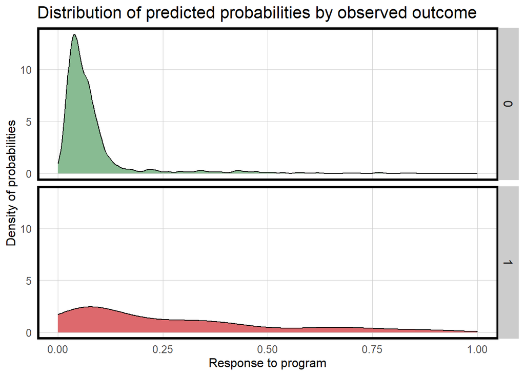

```r
testProbs <- data.frame(Outcome = as.factor(engineered_subsidyTest$y_numeric),
                        Probs = predict(engineered_subsidyModel, engineered_subsidyTest %>% dplyr::select(-y, -X), type= "response"))
testProbs <-
  testProbs %>%
  mutate(predOutcome  = as.factor(ifelse(testProbs$Probs > 0.5 , 1, 0)))

ggplot(testProbs, aes(x = Probs, fill = as.factor(Outcome))) +
  geom_density() +
  facet_grid(Outcome ~ .) +
  scale_fill_manual(values = palette1) + xlim(0, 1) +
  labs(x = "Response to program", y = "Density of probabilities",
       title = "Distribution of predicted probabilities by observed outcome") +
  plotTheme() + theme(strip.text.x = element_text(size = 18),
        legend.position = "none")
```

Now we will look at the summary of the confusion Matrix The accuracy of the model is 89%.

```r
caret::confusionMatrix(testProbs$predOutcome, testProbs$Outcome,
                       positive = "1")
```

```
## Confusion Matrix and Statistics
##
##           Reference
## Prediction    0    1
##          0 1266  131
##          1   17   26
##
##                Accuracy : 0.8972
##                  95% CI : (0.8804, 0.9124)
##     No Information Rate : 0.891
##     P-Value [Acc > NIR] : 0.2378
##
##                   Kappa : 0.2236
##
##  Mcnemar's Test P-Value : <2e-16
##
##             Sensitivity : 0.16561
##             Specificity : 0.98675
##          Pos Pred Value : 0.60465
##          Neg Pred Value : 0.90623
##              Prevalence : 0.10903
##          Detection Rate : 0.01806
##    Detection Prevalence : 0.02986
##       Balanced Accuracy : 0.57618
##
##        'Positive' Class : 1
##
```

The Sensitivity of the model is the proportion of actual positives (1’s) that were predicted to be positive (“True Positive Rate”). The Specificity of the model is the proportion of actual negatives (0’s) that were predicted to be negatives (“True Negative Rate”).

The Sensitivity and Specificity of engineered model is 16% and 98%, respectively. The interpretation is that the model is much better at predicting those who are not going to opt in than those who will. As expected, the model is better at predicting not opting-in given that most of the data has this outcome.

New features, better feature engineering, and a more powerful predictive algorithm would significantly improve this model. Another approach for improving the model is to search for an optimal threshold that can limit the most costly errors that we will do next.

### ROC Curve

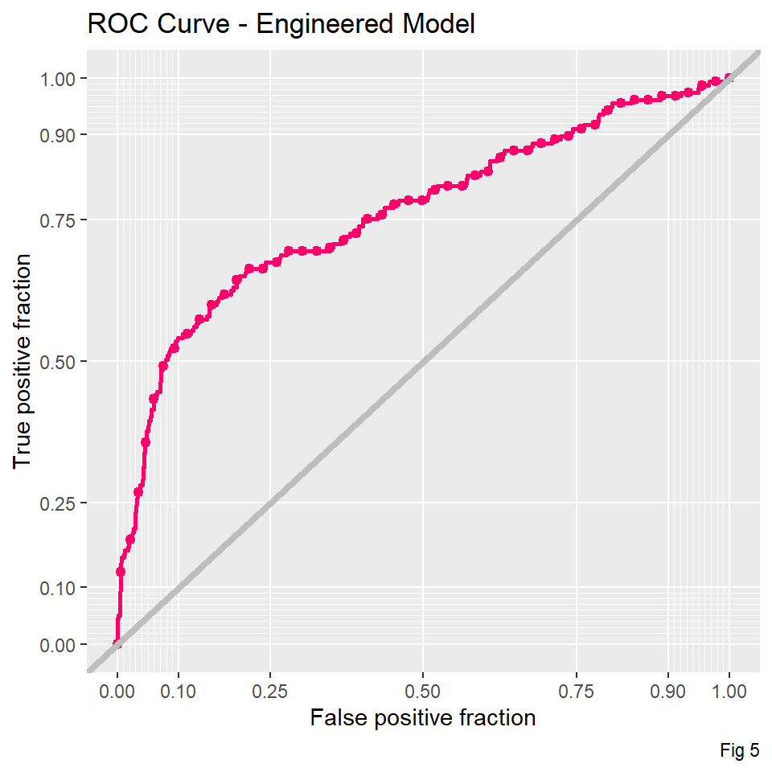

```r
ggplot(testProbs, aes(d = as.numeric(testProbs$Outcome), m = Probs)) +
  geom_roc(n.cuts = 50, labels = FALSE, colour = "#FF006A") +
  style_roc(theme = theme_grey) +
  geom_abline(slope = 1, intercept = 0, size = 1.5, color = 'grey') +
  labs(title = "ROC Curve - Engineered Model", caption= "Fig 5")
```

```r
pROC::auc(testProbs$Outcome, testProbs$Probs)
```

```
## Area under the curve: 0.7613
```

The Receiver Operating Characteristic (ROC) Curve visualizes the relationship between true positive rate and false positive rate for different logistic model thresholds and provides a goodness of fit indicator - Area Under Curve (AUC). Here, we visualize the ROC curve for the engineered model shown in the plot as the pink line. The grey line is the ROC curve for a coin flip.

We will be using the AUC which quantifies the model’s ability to distinguish between two classes. The AUC for our model is **0.761**. An AUC of 0.761 indicates that the model is better than random chance. It means that, on average, the model is able to correctly rank a randomly chosen positive instance higher than a randomly chosen negative instance in about 76.1% of cases. An AUC of 0.761 suggests a moderate level of discrimination. While not perfect, it indicates that the model has some capability to distinguish between the two classes.

## Cost Benefit Analysis

If we predict that a household will take the credit, then HCD allocates (on average) $2,850 per homeowner which includes staff and resources. Given the new targeting algorithm, we should now assume 25% of contacted eligible homeowners receive the credit.

There is also another lens to view this public facing project: the social lens. “The credit allocates $5,000 per homeowner which can be used toward home improvement. Academic researchers in Philadelphia evaluated the program finding that houses that transacted after taking the credit, sold with a $10,000 premium, on average. Homes surrounding the repaired home see an aggregate premium of $56,000, on average.” This means that the state will ultimately benefit when its citizens benefit as well.

Here is the logic for the cost benefit analysis:

**True Positive** - Predicted correctly homeowner would enter credit program; allocated the marketing resources, and 25% ultimately achieved the credit. Funds allocated: $2850 + $5000 Premium the homeowner and neighbors got: $10000 + $56000 Percent of people that could avail this: 25% money spent on 75% of people that didn’t take credit: $2850 Formula: count * (0.25($66000-(5000 + 2850)) - 0.75($2850)) = count * $12400

**True Negative** - Predicted correctly homeowner would not enter the credit program, no marketing resources were allocated, and no credit was allocated. Money spent: $0

**False Positive** - Predicted incorrectly homeowner would enter the credit program; allocated marketing resources; no credit allocated. Money spent: count * $2850

**False Negative** - We predicted that a homeowner would not enter the credit program but they did. These are likely homeowners who signed up for reasons unrelated to the marketing campaign. Thus, we ‘0 out’ this category, assuming the cost/benefit of this is $0.

```r
cost_benefit_table <-
   testProbs %>%
      count(predOutcome, Outcome) %>%
      summarize(True_Negative = sum(n[predOutcome==0 & Outcome==0]),
                True_Positive = sum(n[predOutcome==1 & Outcome==1]),
                False_Negative = sum(n[predOutcome==0 & Outcome==1]),
                False_Positive = sum(n[predOutcome==1 & Outcome==0])) %>%
       gather(Variable, Count) %>%
       mutate(Revenue =
               case_when(Variable == "True_Negative"  ~ Count * 0,
                         Variable == "True_Positive"  ~ (12400 * Count),
                         Variable == "False_Negative" ~ 0 * Count,
                         Variable == "False_Positive" ~ (-2850) * Count)) %>%
    bind_cols(data.frame(Description = c(
              "We predicted correctly homeowner would not take the credit, no marketing resources were allocated.",
              "We predicted correctly homeowner would enter credit program; allocated the marketing resource.",
              "We predicted that a homeowner would not take the credit but they did.",
              "We predicted incorrectly homeowner would take the credit; allocated marketing resources.")))

kable(cost_benefit_table,
       caption = "Cost/Benefit Table") %>% kable_styling()
```

Cost/Benefit Table

| Variable | Count | Revenue | Description |
| --- | --- | --- | --- |
| True_Negative | 1266 | 0 | We predicted correctly homeowner would not take the credit, no marketing resources were allocated. |
| True_Positive | 26 | 322400 | We predicted correctly homeowner would enter credit program; allocated the marketing resource. |
| False_Negative | 131 | 0 | We predicted that a homeowner would not take the credit but they did. |
| False_Positive | 17 | -48450 | We predicted incorrectly homeowner would take the credit; allocated marketing resources. |

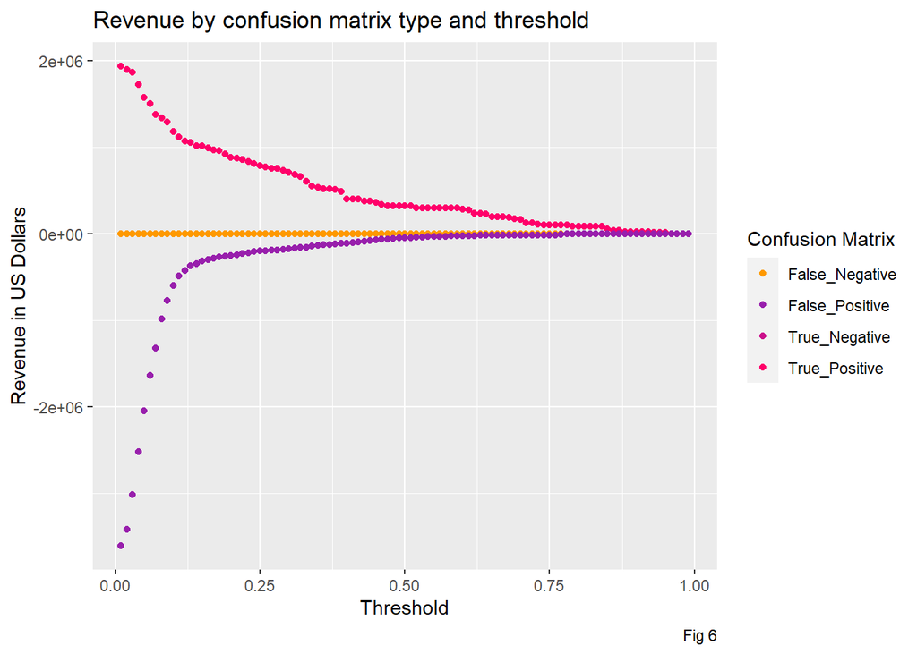

```r
iterateThresholds <- function(data) {
  x = .01
  all_prediction <- data.frame()
  while (x <= 1) {

  this_prediction <-
      testProbs %>%
      mutate(predOutcome = ifelse(Probs > x, 1, 0)) %>%
      count(predOutcome, Outcome) %>%
      summarize(True_Negative = sum(n[predOutcome==0 & Outcome==0]),
                True_Positive = sum(n[predOutcome==1 & Outcome==1]),
                False_Negative = sum(n[predOutcome==0 & Outcome==1]),
                False_Positive = sum(n[predOutcome==1 & Outcome==0])) %>%
     gather(Variable, Count) %>%
   mutate(Revenue =
               ifelse(Variable == "True_Negative", Count * 0,
               ifelse(Variable == "True_Positive", 12400 * Count,
               ifelse(Variable == "False_Negative", 0 * Count,
               ifelse(Variable == "False_Positive", (-2850) * Count, 0)))),
            Threshold = x)

  all_prediction <- rbind(all_prediction, this_prediction)
  x <- x + .01
  }
return(all_prediction)
}

whichThreshold <- iterateThresholds(testProbs2)

whichThreshold_revenue <-
whichThreshold %>%
    group_by(Threshold) %>%
    summarize(Revenue = sum(Revenue))

#confusion matrix
whichThreshold %>%
  ggplot(.,aes(Threshold, Revenue, colour = Variable)) +
  geom_point() +
  scale_colour_manual(values = palette5[c(5, 1:3)]) +
  labs(title = "Revenue by confusion matrix type and threshold",
       y = "Revenue in US Dollars", caption= "Fig 6") +
  guides(colour=guide_legend(title = "Confusion Matrix"))
```

### Threshold as a function of Total Revenue and Total count of Credits

Here is a cost/benefit table using 0.5 as the threshold for the logistic model. To determine an optimal threshold to reach the highest output/ revenue, we create two plots that show how total revenue (Revenue) and the number of individuals who take the credit (CountCredits) change as the threshold changes.

Examining the revenue curve reveals some key insights. The program’s revenue initially starts at a strongly negative value due to substantial marketing expenses. It then experiences rapid growth as more premiums are collected, but eventually tapers off to zero when marketing efforts cease, resulting in no further program-related revenue.

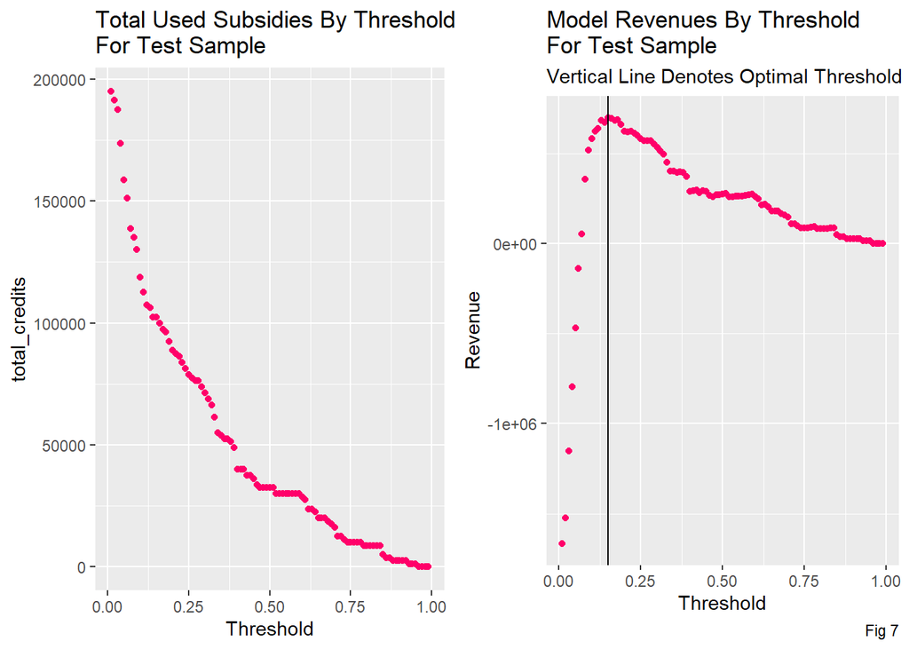

```r
whichThreshold_count <-
whichThreshold %>%
    group_by(Threshold) %>%
    filter(.,Variable == "True_Positive") %>%
    summarize(total_credits = (sum(Count))* 5000 * 0.25)

countplot <-  ggplot(whichThreshold_count)+
  geom_point(aes(x = Threshold, y = total_credits), color= "#FF006A")+
    labs(title = "Total Used Subsidies By Threshold \nFor Test Sample")

whichThreshold_revenue <-
whichThreshold %>%
    group_by(Threshold) %>%
    summarize(Revenue = sum(Revenue))

revenueplot <-  ggplot(whichThreshold_revenue)+
  geom_point(aes(x = Threshold, y = Revenue), color= "#FF006A")+
  geom_vline(xintercept =  pull(arrange(whichThreshold_revenue, -Revenue)[1,1]))+
    labs(title = "Model Revenues By Threshold \nFor Test Sample",
         subtitle = "Vertical Line Denotes Optimal Threshold", caption= "Fig 7")

grid.arrange(countplot, revenueplot, ncol = 2)
```

When the threshold is set to 0.18, it results in a higher number of credits (96,250) and a higher total revenue ($684,050). This threshold may be less stringent in classifying positive cases, resulting in more credits being allocated, but also generating a higher revenue.

When the threshold is set to 0.50, it outputs a lower number of credits (32,500) and a lower total revenue ($273,950). This threshold is more conservative in classifying positive cases, resulting in fewer credits allocated and lower revenue.

```r
whichThreshold_revenue %>%
  filter(Threshold %in% c("0.18", "0.5")) %>%
  kable(caption = "Total Revenue and Total Count of Credits for Optimal Threshold and 0.5 Threshold") %>%
  kable_styling()
```

Total Revenue and Total Count of Credits for Optimal Threshold and 0.5 Threshold

| Threshold | Revenue |
| --- | --- |
| 0.18 | 684050 |
| 0.50 | 273950 |

## Conclusion

Even though the model has an accuracy of 89% and helps with specificity (true false negatives), I would not recommend to put this model in use without more specific variables and better sampling techniques rather than simply taking a random sample of records of previous campaigns. However well the goodness of fit and suggested revenue perform, the model will still not be applicable without taking into considerations more specific datapoints and political and housing conditions of the next campaign. Looking at the high number of people that don’t opt in, the model might be heavily skewed because of this data imbalance and generalization.

A sample that is well-balanced for the two classes (yes and no) might lead to better model results. In addition to focusing on a more targeted audience using classification model, HCD can also focus or allocate money towards workshops and targeted audience so that it caters for eligible homeowners rather and ensures better response rate.